# MixedRegression

# Assumptions

For this model,

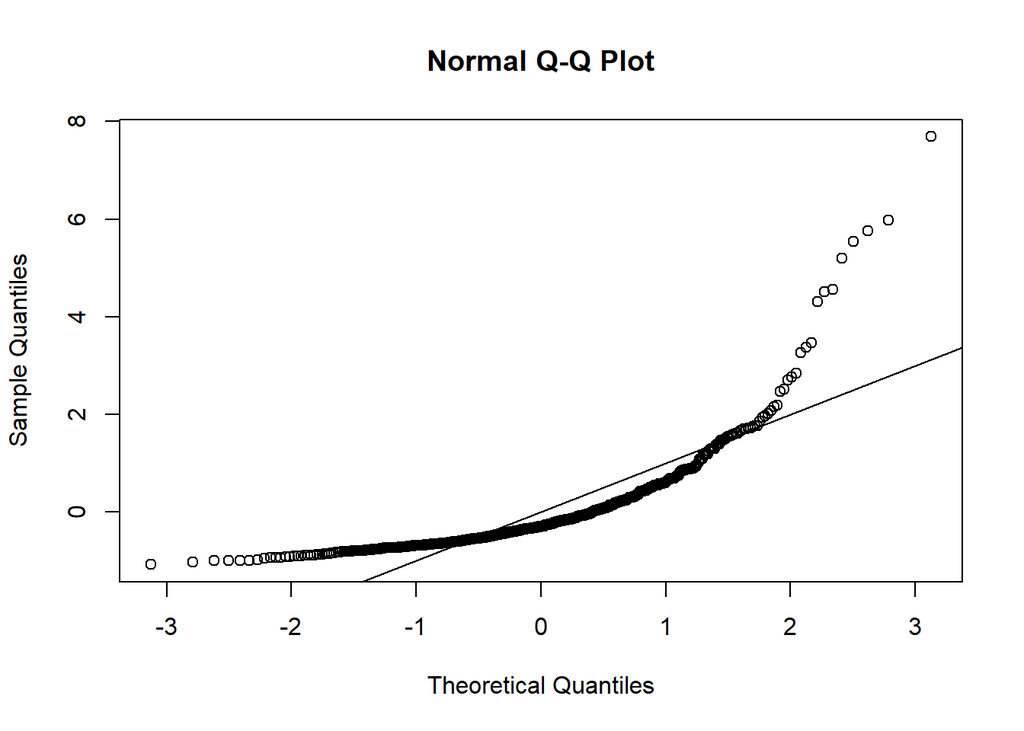

```r
screen = lme(offset ~ chin,
             data = data_trial_fix,
             method = 'ML',
             na.action = "na.omit",
             random = ~ chin | run_id,
             control = lmeControl(msMaxIter = 200))
standardized = as.data.frame(scale(screen$residuals))
standardized = standardized$fixed
fitted = scale(fitted.values(screen))
qqnorm(standardized)
abline(0, 1)
```

Normality got worse

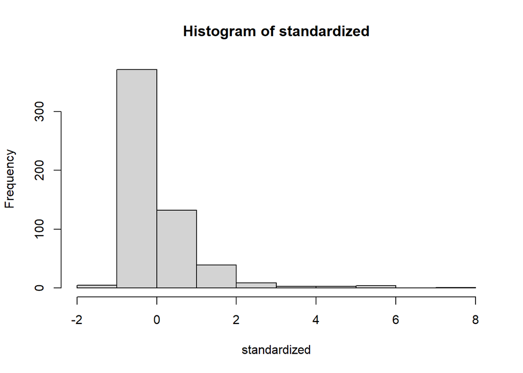

```r
hist(standardized)
```

Heteroscedasticity got worse Concentration of dots is heavily on the left side

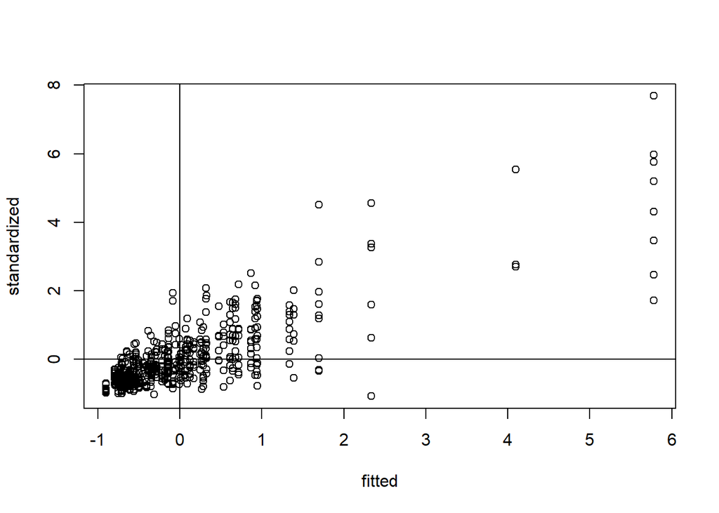

```r
plot(fitted, standardized)
abline(0, 0)
abline(v=0)
```

## Effects

Varianzaufkl?rung: Pseudo-R? (VL11 F18f.)

# More models?

Kontexteffekte (GRO-Zentrierung, VL10)?

# Assumptions

Sources: - https://www.youtube.com/watch?v=UvyxSqEXBwc - https://www.pythonfordatascience.org/mixed-effects-regression-python/

## Accuracy

## Outliers

## Multicollinearity

## Linearity

## Normality

Voraussetzungen (Eid2015, p. 747) - Residuen unabh?ngig und identisch normalverteilt, u.a.

## Homogeneity

## Homoscedasticity